# Introduction to geocomputation with R

Duc-Quang Nguyen

2022/05/19

# Simple features: *sf*

Supports common vector geometry types

Source: Geocomputation with R by Robin Lovelace

*sf* can represent all common vector geometry types (raster data classes are not supported by sf): points, lines, polygons and their respective ‘multi’ versions (which group together features of the same type into a single feature). sf also supports geometry collections, which can contain multiple geometry types in a single object.

Source: Geocomputation with R by Robin Lovelace

## [Coordinate reference system (CRS)](https://geocompr.robinlovelace.net/spatial-class.html#crs-intro)

How the spatial elements of the data relate to the surface of the Earth. That coordinate systems are a key component of geographic objects

Knowing which CRS your data is in, and whether it is in geographic (lon/lat) or projected (typically meters), is important and has consequences for how R handles spatial and geometry operations

Source: Geocomputation with R by Robin Lovelace

# Carte choroplèthe par municipalité

```r
library(tidyverse)
library(sf)
library(swissdd) # Données historiques et en temps réel des votations fédérales
#require("revealjs")
```

## Load Swiss geo data

Data from [Office fédéral de la statistique - Limites communales généralisées: géodonnées](https://www.bfs.admin.ch/bfs/fr/home/services/geostat/geodonnees-statistique-federale/limites-administratives/limites-communales-generalisees.assetdetail.22484210.html)

```r
muni <- st_read("shp/g2g22.shp")
```

## Anatomy of a sf object

```r
str(muni)
```

```
## Classes 'sf' and 'data.frame':   2148 obs. of  20 variables:
##  $ GMDHISTID: num  13256 11742 11801 11992 12249 ...
##  $ GMDNR    : num  1 2 3 4 5 6 7 8 9 10 ...
##  $ GMDNAME  : chr  "Aeugst am Albis" "Affoltern am Albis" "Bonstetten" "Hausen am Albis" ...
##  $ BZHISTID : num  10053 10053 10053 10053 10053 ...
##  $ BZNR     : num  101 101 101 101 101 101 101 101 101 101 ...
##  $ KTNR     : num  1 1 1 1 1 1 1 1 1 1 ...
##  $ GRNR     : num  4 4 4 4 4 4 4 4 4 4 ...
##  $ AREA_HA  : num  791 1059 743 1360 653 ...
##  $ E_MIN    : num  2678111 2673826 2675745 2680394 2674866 ...
##  $ E_MAX    : num  2681155 2678584 2679642 2686463 2678972 ...
##  $ N_MIN    : num  1234561 1235208 1238997 1230185 1238053 ...
##  $ N_MAX    : num  1238544 1239338 1243159 1236411 1241034 ...
##  $ E_CNTR   : num  2679300 2676800 2677800 2682900 2676400 ...
##  $ N_CNTR   : num  1235700 1236800 1241000 1233100 1239000 ...
##  $ Z_MIN    : num  533 440 502 524 475 463 412 386 432 383 ...
##  $ Z_MAX    : num  887 749 715 915 745 621 504 476 658 520 ...
##  $ Z_AVG    : num  685 529 581 673 560 557 454 414 506 440 ...
##  $ Z_MED    : num  673 502 583 653 543 559 454 410 493 439 ...
##  $ Z_CNTR   : num  700 490 544 610 503 573 431 400 471 453 ...
##  $ geometry :sfc_MULTIPOLYGON of length 2148; first list element: List of 1
##   ..$ :List of 1
##   .. ..$ : num [1:24, 1:2] 2678219 2678560 2678206 2678196 2678259 ...
##   ..- attr(*, "class")= chr [1:3] "XY" "MULTIPOLYGON" "sfg"
##  - attr(*, "sf_column")= chr "geometry"
##  - attr(*, "agr")= Factor w/ 3 levels "constant","aggregate",..: NA NA NA NA NA NA NA NA NA NA ...
##   ..- attr(*, "names")= chr [1:19] "GMDHISTID" "GMDNR" "GMDNAME" "BZHISTID" ...
```

## Quick sf plots & simplify

```r
# Quickly plot the geodata by selecting only the geometry
muni %>% select() %>% plot
```

[output not shown]

```r
# This will color the map by the features
# plot(muni)

# ggpplot2 way to visualize geo data
ggplot(muni) +
  geom_sf()
```

[output not shown]

```r
# dTolerance must be specified in meters.
muni %>%
  st_simplify(preserveTopology = TRUE, dTolerance = 1000) %>%
  ggplot() + geom_sf()
```

[output not shown]

```r
muni <- muni %>%
  st_simplify(preserveTopology = TRUE, dTolerance = 70) #%>%
  #select %>% plot()
```

## Basic choropleth of Swiss municipalities by their canton

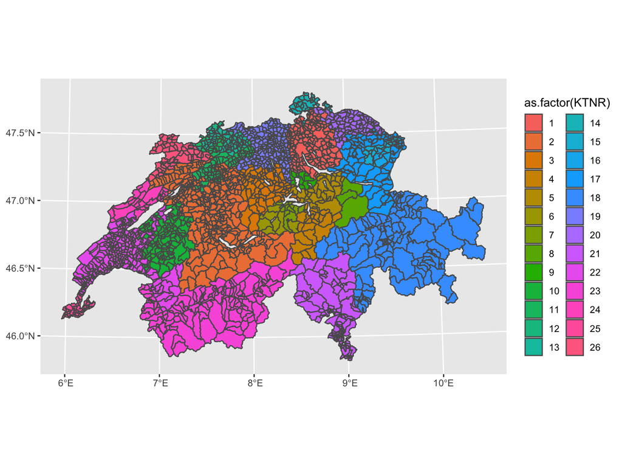

```r
ggplot(muni) +
  geom_sf(aes(fill = as.factor(KTNR)))
```

## Improved Choropleth Swiss of municipalities by their canton

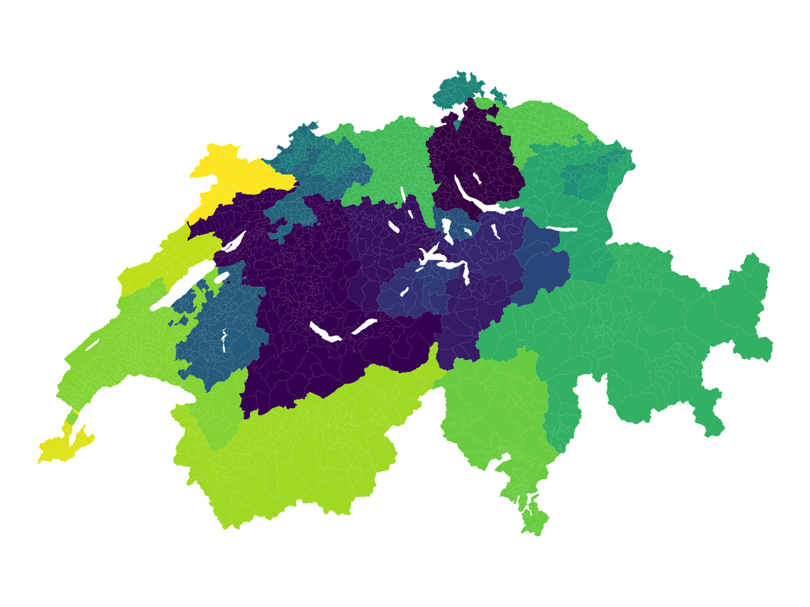

```r
ggplot(muni) +
  # Set no linewidth with size argument
  geom_sf(aes(fill = as.factor(KTNR)), size = 0) +
  # Hide colour scale
  scale_fill_viridis_d(guide = 'none') +
  # Remove graticule
  theme_void()
```

# Carte choroplèthe par municipalité de la votation fédérale «Lex Netflix» 15.05.2022

Données historiques et en temps réel des votations fédérales & cantonales suisses:  
[swissdd](https://politanch.github.io/swissdd/)

id vote «Lex Netflix»: 6550

## Get the votation results by municipality

```r
muni_2022_05_15_results <- swissdd::get_nationalvotes(
  geolevel = "municipality", from_date = "2022-05-15",
  to_date =  "2022-05-15", language = "FR")

# str(muni_2022_05_15_results)
#  muni_2022_05_15_results$name %>% unique()

ln_df <- muni_2022_05_15_results %>%
  filter(id == 6550) %>%
  select(canton_name:mun_name, jaStimmenInProzent, gueltigeStimmen)
```

## Bind to geodata and plot

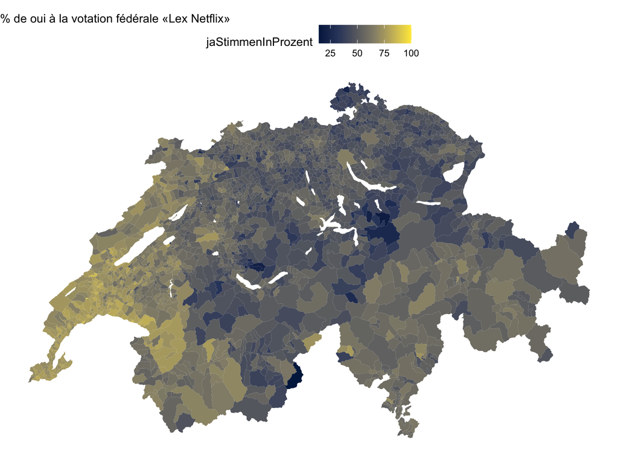

```r
ln_df <- left_join(
  ln_df %>% mutate(mun_id = as.numeric(mun_id)),
  muni %>% select(GMDNR:GRNR),
  by = c("mun_id" = "GMDNR")
  # To ensure the join returns a sf object
) %>% st_as_sf()

ln_map <- ggplot(ln_df) +
  geom_sf(aes(fill = jaStimmenInProzent), size = 0) +
  scale_fill_viridis_c(option = "E") +
  theme_void() +
  theme(legend.position = "top") +
  labs(subtitle = "% de oui à la votation fédérale «Lex Netflix»")
ln_map
```

https://www.rstudio.com/resources/cheatsheets/